# Risk Factor Analysis

## Outcome Variable

**Outcome Variable:** ever_swasted

## Predictor Variables

**Intervention Variable:** fhtcm

**Adjustment Set:**

unadjusted

## Stratifying Variables

The analysis was stratified on these variable(s):

- agecat
- studyid
- country

## Data Summary

| agecat | studyid | country | fhtcm | ever_swasted | n_cell | n |
| --- | --- | --- | --- | --- | --- | --- |
| 0-24 months | ki1000304b-SAS-CompFeed | INDIA | >=167 cm | 0 | 357 | 895 |
| 0-24 months | ki1000304b-SAS-CompFeed | INDIA | >=167 cm | 1 | 50 | 895 |
| 0-24 months | ki1000304b-SAS-CompFeed | INDIA | <162 cm | 0 | 195 | 895 |
| 0-24 months | ki1000304b-SAS-CompFeed | INDIA | <162 cm | 1 | 31 | 895 |
| 0-24 months | ki1000304b-SAS-CompFeed | INDIA | [162-167) cm | 0 | 221 | 895 |
| 0-24 months | ki1000304b-SAS-CompFeed | INDIA | [162-167) cm | 1 | 41 | 895 |
| 0-24 months | ki1000304b-SAS-FoodSuppl | INDIA | >=167 cm | 0 | 91 | 399 |
| 0-24 months | ki1000304b-SAS-FoodSuppl | INDIA | >=167 cm | 1 | 15 | 399 |
| 0-24 months | ki1000304b-SAS-FoodSuppl | INDIA | <162 cm | 0 | 131 | 399 |
| 0-24 months | ki1000304b-SAS-FoodSuppl | INDIA | <162 cm | 1 | 32 | 399 |
| 0-24 months | ki1000304b-SAS-FoodSuppl | INDIA | [162-167) cm | 0 | 110 | 399 |
| 0-24 months | ki1000304b-SAS-FoodSuppl | INDIA | [162-167) cm | 1 | 20 | 399 |
| 0-24 months | ki1101329-Keneba | GAMBIA | >=167 cm | 0 | 1012 | 1933 |
| 0-24 months | ki1101329-Keneba | GAMBIA | >=167 cm | 1 | 236 | 1933 |
| 0-24 months | ki1101329-Keneba | GAMBIA | <162 cm | 0 | 99 | 1933 |
| 0-24 months | ki1101329-Keneba | GAMBIA | <162 cm | 1 | 33 | 1933 |
| 0-24 months | ki1101329-Keneba | GAMBIA | [162-167) cm | 0 | 454 | 1933 |
| 0-24 months | ki1101329-Keneba | GAMBIA | [162-167) cm | 1 | 99 | 1933 |
| 0-24 months | ki1119695-PROBIT | BELARUS | >=167 cm | 0 | 10729 | 12537 |
| 0-24 months | ki1119695-PROBIT | BELARUS | >=167 cm | 1 | 1015 | 12537 |
| 0-24 months | ki1119695-PROBIT | BELARUS | <162 cm | 0 | 157 | 12537 |
| 0-24 months | ki1119695-PROBIT | BELARUS | <162 cm | 1 | 11 | 12537 |
| 0-24 months | ki1119695-PROBIT | BELARUS | [162-167) cm | 0 | 576 | 12537 |
| 0-24 months | ki1119695-PROBIT | BELARUS | [162-167) cm | 1 | 49 | 12537 |
| 0-24 months | ki1135781-COHORTS | GUATEMALA | >=167 cm | 0 | 61 | 495 |
| 0-24 months | ki1135781-COHORTS | GUATEMALA | >=167 cm | 1 | 2 | 495 |
| 0-24 months | ki1135781-COHORTS | GUATEMALA | <162 cm | 0 | 273 | 495 |
| 0-24 months | ki1135781-COHORTS | GUATEMALA | <162 cm | 1 | 20 | 495 |
| 0-24 months | ki1135781-COHORTS | GUATEMALA | [162-167) cm | 0 | 130 | 495 |
| 0-24 months | ki1135781-COHORTS | GUATEMALA | [162-167) cm | 1 | 9 | 495 |

[output cut: 60 more lines]

The following strata were considered:

- agecat: 0-24 months, studyid: ki1000304b-SAS-CompFeed, country: INDIA
- agecat: 0-24 months, studyid: ki1000304b-SAS-FoodSuppl, country: INDIA
- agecat: 0-24 months, studyid: ki1101329-Keneba, country: GAMBIA
- agecat: 0-24 months, studyid: ki1119695-PROBIT, country: BELARUS
- agecat: 0-24 months, studyid: ki1135781-COHORTS, country: GUATEMALA
- agecat: 0-6 months, studyid: ki1000304b-SAS-CompFeed, country: INDIA
- agecat: 0-6 months, studyid: ki1000304b-SAS-FoodSuppl, country: INDIA
- agecat: 0-6 months, studyid: ki1101329-Keneba, country: GAMBIA
- agecat: 0-6 months, studyid: ki1119695-PROBIT, country: BELARUS
- agecat: 0-6 months, studyid: ki1135781-COHORTS, country: GUATEMALA
- agecat: 6-24 months, studyid: ki1000304b-SAS-CompFeed, country: INDIA
- agecat: 6-24 months, studyid: ki1000304b-SAS-FoodSuppl, country: INDIA
- agecat: 6-24 months, studyid: ki1101329-Keneba, country: GAMBIA
- agecat: 6-24 months, studyid: ki1119695-PROBIT, country: BELARUS
- agecat: 6-24 months, studyid: ki1135781-COHORTS, country: GUATEMALA

### Dropped Strata

Some strata were dropped due to rare outcomes:

- agecat: 0-24 months, studyid: ki1135781-COHORTS, country: GUATEMALA
- agecat: 0-6 months, studyid: ki1000304b-SAS-FoodSuppl, country: INDIA
- agecat: 0-6 months, studyid: ki1135781-COHORTS, country: GUATEMALA
- agecat: 6-24 months, studyid: ki1119695-PROBIT, country: BELARUS
- agecat: 6-24 months, studyid: ki1135781-COHORTS, country: GUATEMALA

## Methods Detail

We’re interested in the causal parameters $E[Y_a]$ for all values of $a \in \mathcal{A}$. These parameters represent the mean outcome if, possibly contrary to fact, we intervened to set all units to have $A=a$. Under the randomization and positivity assumptions, these are identified by the statistical parameters $\psi_a=E_W[E_{Y|A,W}(Y|A=a,W)]$. In addition, we’re interested in the mean of $Y$, $E[Y]$ under no intervention (the observed mean). We will estimate these parameters by using SuperLearner to fit the relevant likelihood factors – $E_{Y|A,W}(Y|A=a,W)$ and $p(A=a|W)$, and then updating our likelihood fit using a joint TMLE.

For unadjusted analyses ($W=\{\}$), initial likelihoods were estimated using Lrnr_glm to estimate the simple $E(Y|A)$ and Lrnr_mean to estimate $p(A)$. For adjusted analyses, a small library containing Lrnr_glmnet, Lrnr_xgboost, and Lrnr_mean was used.

Having estimated these parameters, we will then use the delta method to estimate relative risks and attributable risks relative to a prespecified baseline level of $A$.

# Results Detail

## Results Plots

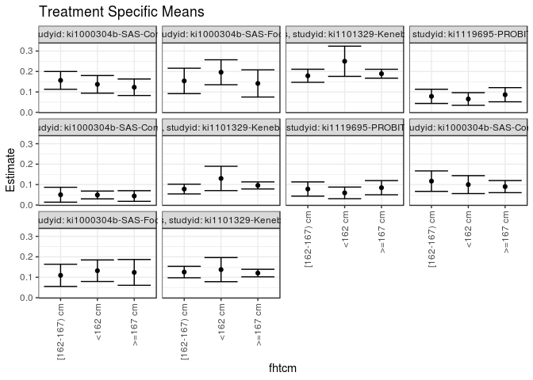

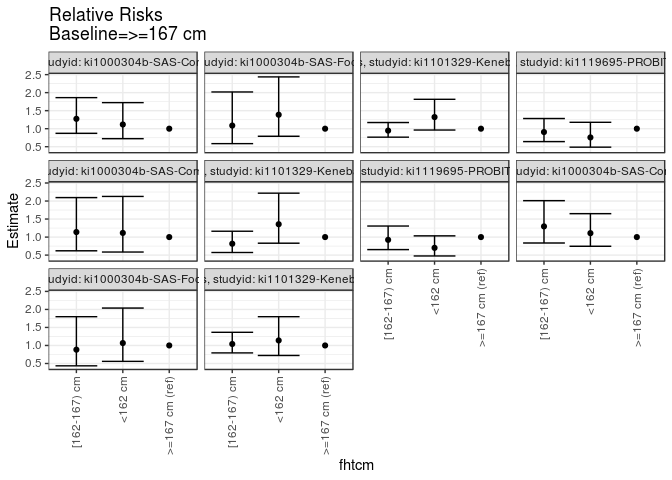

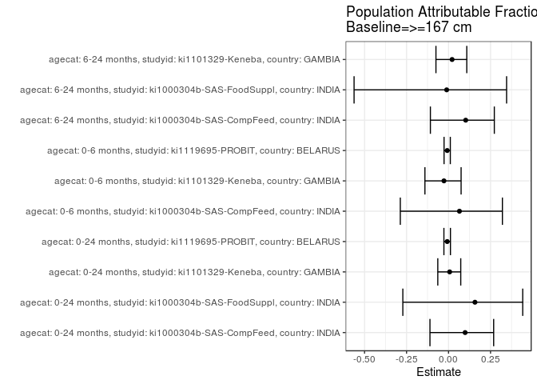

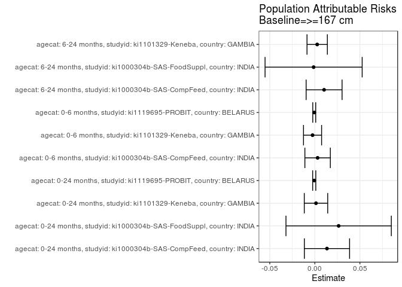

## Results Table

### Parameter: TSM

| agecat | studyid | country | intervention_level | baseline_level | estimate | ci_lower | ci_upper |
| --- | --- | --- | --- | --- | --- | --- | --- |
| 0-24 months | ki1000304b-SAS-CompFeed | INDIA | >=167 cm | NA | 0.1228501 | 0.0824766 | 0.1632236 |
| 0-24 months | ki1000304b-SAS-CompFeed | INDIA | <162 cm | NA | 0.1371681 | 0.0940387 | 0.1802976 |
| 0-24 months | ki1000304b-SAS-CompFeed | INDIA | [162-167) cm | NA | 0.1564885 | 0.1129364 | 0.2000407 |
| 0-24 months | ki1000304b-SAS-FoodSuppl | INDIA | >=167 cm | NA | 0.1415094 | 0.0750739 | 0.2079450 |
| 0-24 months | ki1000304b-SAS-FoodSuppl | INDIA | <162 cm | NA | 0.1963190 | 0.1352639 | 0.2573742 |
| 0-24 months | ki1000304b-SAS-FoodSuppl | INDIA | [162-167) cm | NA | 0.1538462 | 0.0917465 | 0.2159458 |
| 0-24 months | ki1101329-Keneba | GAMBIA | >=167 cm | NA | 0.1891026 | 0.1673713 | 0.2108338 |
| 0-24 months | ki1101329-Keneba | GAMBIA | <162 cm | NA | 0.2500000 | 0.1761120 | 0.3238880 |
| 0-24 months | ki1101329-Keneba | GAMBIA | [162-167) cm | NA | 0.1790235 | 0.1470627 | 0.2109844 |
| 0-24 months | ki1119695-PROBIT | BELARUS | >=167 cm | NA | 0.0864271 | 0.0518425 | 0.1210118 |
| 0-24 months | ki1119695-PROBIT | BELARUS | <162 cm | NA | 0.0654762 | 0.0345673 | 0.0963851 |
| 0-24 months | ki1119695-PROBIT | BELARUS | [162-167) cm | NA | 0.0784000 | 0.0436737 | 0.1131263 |
| 0-6 months | ki1000304b-SAS-CompFeed | INDIA | >=167 cm | NA | 0.0442260 | 0.0182321 | 0.0702200 |
| 0-6 months | ki1000304b-SAS-CompFeed | INDIA | <162 cm | NA | 0.0493274 | 0.0302386 | 0.0684162 |
| 0-6 months | ki1000304b-SAS-CompFeed | INDIA | [162-167) cm | NA | 0.0503876 | 0.0139316 | 0.0868436 |
| 0-6 months | ki1101329-Keneba | GAMBIA | >=167 cm | NA | 0.0958781 | 0.0785993 | 0.1131570 |
| 0-6 months | ki1101329-Keneba | GAMBIA | <162 cm | NA | 0.1300813 | 0.0706154 | 0.1895472 |
| 0-6 months | ki1101329-Keneba | GAMBIA | [162-167) cm | NA | 0.0781893 | 0.0543139 | 0.1020647 |
| 0-6 months | ki1119695-PROBIT | BELARUS | >=167 cm | NA | 0.0848944 | 0.0502366 | 0.1195522 |
| 0-6 months | ki1119695-PROBIT | BELARUS | <162 cm | NA | 0.0595238 | 0.0311719 | 0.0878758 |
| 0-6 months | ki1119695-PROBIT | BELARUS | [162-167) cm | NA | 0.0784000 | 0.0436737 | 0.1131263 |
| 6-24 months | ki1000304b-SAS-CompFeed | INDIA | >=167 cm | NA | 0.0902062 | 0.0605940 | 0.1198184 |
| 6-24 months | ki1000304b-SAS-CompFeed | INDIA | <162 cm | NA | 0.1000000 | 0.0561864 | 0.1438136 |
| 6-24 months | ki1000304b-SAS-CompFeed | INDIA | [162-167) cm | NA | 0.1169355 | 0.0669204 | 0.1669506 |
| 6-24 months | ki1000304b-SAS-FoodSuppl | INDIA | >=167 cm | NA | 0.1238095 | 0.0607306 | 0.1868885 |
| 6-24 months | ki1000304b-SAS-FoodSuppl | INDIA | <162 cm | NA | 0.1320755 | 0.0793821 | 0.1847689 |
| 6-24 months | ki1000304b-SAS-FoodSuppl | INDIA | [162-167) cm | NA | 0.1093750 | 0.0552367 | 0.1635133 |
| 6-24 months | ki1101329-Keneba | GAMBIA | >=167 cm | NA | 0.1205734 | 0.1020360 | 0.1391107 |
| 6-24 months | ki1101329-Keneba | GAMBIA | <162 cm | NA | 0.1374046 | 0.0784342 | 0.1963750 |
| 6-24 months | ki1101329-Keneba | GAMBIA | [162-167) cm | NA | 0.1254682 | 0.0973654 | 0.1535710 |

### Parameter: E(Y)

| agecat | studyid | country | intervention_level | baseline_level | estimate | ci_lower | ci_upper |
| --- | --- | --- | --- | --- | --- | --- | --- |
| 0-24 months | ki1000304b-SAS-CompFeed | INDIA | NA | NA | 0.1363128 | 0.1083079 | 0.1643178 |
| 0-24 months | ki1000304b-SAS-FoodSuppl | INDIA | NA | NA | 0.1679198 | 0.1311966 | 0.2046430 |
| 0-24 months | ki1101329-Keneba | GAMBIA | NA | NA | 0.1903777 | 0.1728714 | 0.2078839 |
| 0-24 months | ki1119695-PROBIT | BELARUS | NA | NA | 0.0857462 | 0.0517958 | 0.1196966 |
| 0-6 months | ki1000304b-SAS-CompFeed | INDIA | NA | NA | 0.0472973 | 0.0247949 | 0.0697997 |
| 0-6 months | ki1101329-Keneba | GAMBIA | NA | NA | 0.0933333 | 0.0796017 | 0.1070650 |
| 0-6 months | ki1119695-PROBIT | BELARUS | NA | NA | 0.0842307 | 0.0501567 | 0.1183046 |
| 6-24 months | ki1000304b-SAS-CompFeed | INDIA | NA | NA | 0.1004785 | 0.0697945 | 0.1311624 |
| 6-24 months | ki1000304b-SAS-FoodSuppl | INDIA | NA | NA | 0.1224490 | 0.0899572 | 0.1549408 |
| 6-24 months | ki1101329-Keneba | GAMBIA | NA | NA | 0.1231767 | 0.1082011 | 0.1381522 |

### Parameter: RR

| agecat | studyid | country | intervention_level | baseline_level | estimate | ci_lower | ci_upper |
| --- | --- | --- | --- | --- | --- | --- | --- |
| 0-24 months | ki1000304b-SAS-CompFeed | INDIA | >=167 cm | >=167 cm | 1.0000000 | 1.0000000 | 1.000000 |
| 0-24 months | ki1000304b-SAS-CompFeed | INDIA | <162 cm | >=167 cm | 1.1165487 | 0.7235335 | 1.723045 |
| 0-24 months | ki1000304b-SAS-CompFeed | INDIA | [162-167) cm | >=167 cm | 1.2738168 | 0.8714557 | 1.861953 |
| 0-24 months | ki1000304b-SAS-FoodSuppl | INDIA | >=167 cm | >=167 cm | 1.0000000 | 1.0000000 | 1.000000 |
| 0-24 months | ki1000304b-SAS-FoodSuppl | INDIA | <162 cm | >=167 cm | 1.3873211 | 0.7899635 | 2.436391 |
| 0-24 months | ki1000304b-SAS-FoodSuppl | INDIA | [162-167) cm | >=167 cm | 1.0871795 | 0.5853421 | 2.019262 |
| 0-24 months | ki1101329-Keneba | GAMBIA | >=167 cm | >=167 cm | 1.0000000 | 1.0000000 | 1.000000 |
| 0-24 months | ki1101329-Keneba | GAMBIA | <162 cm | >=167 cm | 1.3220339 | 0.9627744 | 1.815351 |
| 0-24 months | ki1101329-Keneba | GAMBIA | [162-167) cm | >=167 cm | 0.9467006 | 0.7656044 | 1.170633 |
| 0-24 months | ki1119695-PROBIT | BELARUS | >=167 cm | >=167 cm | 1.0000000 | 1.0000000 | 1.000000 |
| 0-24 months | ki1119695-PROBIT | BELARUS | <162 cm | >=167 cm | 0.7575886 | 0.4876292 | 1.177002 |
| 0-24 months | ki1119695-PROBIT | BELARUS | [162-167) cm | >=167 cm | 0.9071228 | 0.6419231 | 1.281885 |
| 0-6 months | ki1000304b-SAS-CompFeed | INDIA | >=167 cm | >=167 cm | 1.0000000 | 1.0000000 | 1.000000 |
| 0-6 months | ki1000304b-SAS-CompFeed | INDIA | <162 cm | >=167 cm | 1.1153463 | 0.5847078 | 2.127554 |
| 0-6 months | ki1000304b-SAS-CompFeed | INDIA | [162-167) cm | >=167 cm | 1.1393195 | 0.6195969 | 2.094989 |
| 0-6 months | ki1101329-Keneba | GAMBIA | >=167 cm | >=167 cm | 1.0000000 | 1.0000000 | 1.000000 |
| 0-6 months | ki1101329-Keneba | GAMBIA | <162 cm | >=167 cm | 1.3567358 | 0.8300219 | 2.217691 |
| 0-6 months | ki1101329-Keneba | GAMBIA | [162-167) cm | >=167 cm | 0.8155071 | 0.5720586 | 1.162559 |
| 0-6 months | ki1119695-PROBIT | BELARUS | >=167 cm | >=167 cm | 1.0000000 | 1.0000000 | 1.000000 |
| 0-6 months | ki1119695-PROBIT | BELARUS | <162 cm | >=167 cm | 0.7011511 | 0.4756268 | 1.033610 |
| 0-6 months | ki1119695-PROBIT | BELARUS | [162-167) cm | >=167 cm | 0.9235001 | 0.6525026 | 1.307048 |
| 6-24 months | ki1000304b-SAS-CompFeed | INDIA | >=167 cm | >=167 cm | 1.0000000 | 1.0000000 | 1.000000 |
| 6-24 months | ki1000304b-SAS-CompFeed | INDIA | <162 cm | >=167 cm | 1.1085714 | 0.7450190 | 1.649529 |
| 6-24 months | ki1000304b-SAS-CompFeed | INDIA | [162-167) cm | >=167 cm | 1.2963134 | 0.8359607 | 2.010176 |
| 6-24 months | ki1000304b-SAS-FoodSuppl | INDIA | >=167 cm | >=167 cm | 1.0000000 | 1.0000000 | 1.000000 |
| 6-24 months | ki1000304b-SAS-FoodSuppl | INDIA | <162 cm | >=167 cm | 1.0667634 | 0.5585133 | 2.037524 |
| 6-24 months | ki1000304b-SAS-FoodSuppl | INDIA | [162-167) cm | >=167 cm | 0.8834135 | 0.4341792 | 1.797459 |
| 6-24 months | ki1101329-Keneba | GAMBIA | >=167 cm | >=167 cm | 1.0000000 | 1.0000000 | 1.000000 |
| 6-24 months | ki1101329-Keneba | GAMBIA | <162 cm | >=167 cm | 1.1395932 | 0.7223764 | 1.797778 |
| 6-24 months | ki1101329-Keneba | GAMBIA | [162-167) cm | >=167 cm | 1.0405961 | 0.7930426 | 1.365425 |

### Parameter: PAR

| agecat | studyid | country | intervention_level | baseline_level | estimate | ci_lower | ci_upper |
| --- | --- | --- | --- | --- | --- | --- | --- |
| 0-24 months | ki1000304b-SAS-CompFeed | INDIA | >=167 cm | NA | 0.0134627 | -0.0116304 | 0.0385558 |
| 0-24 months | ki1000304b-SAS-FoodSuppl | INDIA | >=167 cm | NA | 0.0264104 | -0.0320461 | 0.0848668 |
| 0-24 months | ki1101329-Keneba | GAMBIA | >=167 cm | NA | 0.0012751 | -0.0117220 | 0.0142722 |
| 0-24 months | ki1119695-PROBIT | BELARUS | >=167 cm | NA | -0.0006809 | -0.0024227 | 0.0010609 |
| 0-6 months | ki1000304b-SAS-CompFeed | INDIA | >=167 cm | NA | 0.0030713 | -0.0110564 | 0.0171989 |
| 0-6 months | ki1101329-Keneba | GAMBIA | >=167 cm | NA | -0.0025448 | -0.0125851 | 0.0074955 |
| 0-6 months | ki1119695-PROBIT | BELARUS | >=167 cm | NA | -0.0006637 | -0.0023049 | 0.0009774 |
| 6-24 months | ki1000304b-SAS-CompFeed | INDIA | >=167 cm | NA | 0.0102723 | -0.0096717 | 0.0302162 |
| 6-24 months | ki1000304b-SAS-FoodSuppl | INDIA | >=167 cm | NA | -0.0013605 | -0.0552408 | 0.0525198 |
| 6-24 months | ki1101329-Keneba | GAMBIA | >=167 cm | NA | 0.0026033 | -0.0086902 | 0.0138968 |

### Parameter: PAF

| agecat | studyid | country | intervention_level | baseline_level | estimate | ci_lower | ci_upper |
| --- | --- | --- | --- | --- | --- | --- | --- |
| 0-24 months | ki1000304b-SAS-CompFeed | INDIA | >=167 cm | NA | 0.0987634 | -0.1106214 | 0.2686731 |
| 0-24 months | ki1000304b-SAS-FoodSuppl | INDIA | >=167 cm | NA | 0.1572796 | -0.2720625 | 0.4417117 |
| 0-24 months | ki1101329-Keneba | GAMBIA | >=167 cm | NA | 0.0066977 | -0.0639716 | 0.0726730 |
| 0-24 months | ki1119695-PROBIT | BELARUS | >=167 cm | NA | -0.0079411 | -0.0275942 | 0.0113361 |
| 0-6 months | ki1000304b-SAS-CompFeed | INDIA | >=167 cm | NA | 0.0649350 | -0.2871609 | 0.3207171 |
| 0-6 months | ki1101329-Keneba | GAMBIA | >=167 cm | NA | -0.0272657 | -0.1406089 | 0.0748144 |
| 0-6 months | ki1119695-PROBIT | BELARUS | >=167 cm | NA | -0.0078800 | -0.0267143 | 0.0106088 |
| 6-24 months | ki1000304b-SAS-CompFeed | INDIA | >=167 cm | NA | 0.1022337 | -0.1080342 | 0.2725997 |
| 6-24 months | ki1000304b-SAS-FoodSuppl | INDIA | >=167 cm | NA | -0.0111111 | -0.5624105 | 0.3456613 |
| 6-24 months | ki1101329-Keneba | GAMBIA | >=167 cm | NA | 0.0211347 | -0.0749535 | 0.1086338 |